# Top 1 Group Final Project

Hao Wang (haow12), Qiuning Ge (qiuning2), Chenhan Xu (chenhan2), and Zhongyu Wu (zhongyu6)

13 December, 2019

```r
theme_set(theme_light())
```

# Abstract

# Introduction

# Methods

## Data

```r
bank_full = read.csv("bank-additional-full.csv")
```

```r
bank_new = bank_full %>%
  filter(
    bank_full$job != "unknown" &
      bank_full$marital != "unknown" &
      bank_full$education != "unknown" &
      bank_full$loan != "unknown" & bank_full$housing != "unknown"
  )
```

```r
#set.seed(42)
idx = createDataPartition(bank_new$y, p = 0.8, list = FALSE)
bank_trn = bank_new[idx, ]
bank_tst = bank_new[-idx, ]
```

## Modeling

### Binary Classification

# Results

# Discussion

# Appendix

## Data Dictionary

- `age` - age in years
- `job` - type of job
- `marital` - marital status
- `education` - education level
- `default` - whether this client has credit in default
- `housing` - whether this client has housing loan
- `loan` - whether this client has personal loan
- `contact` - contact communication type
- `month` - last contact month of year
- `day_of_week` - last contact day of the week
- `duration` - last contact duration in seconds
- `campaign` - number of contacts performed during this campaign and for this client
- `pdays` - number of days that passed by after the client was last contacted from a previous campaign
- `previous` - number of contacts performed before this campaign and for this client
- `poutcome` - outcome of the previous marketing campaign
- `emp.var.rate` - employment variation rate
- `cons.price.idx` - consumer price index
- `cons.conf.idx` - consumer confidence index
- `euribor3m` - euribor 3 month rate
- `nr.employed` - number of employees
- `y` - whether the client has subscribed a term deposit?

See the UCI Machine Learning Repository for additional documentation.

## EDA

```r
plot_1 = bank_new %>%
  ggplot(aes(x = age, col = job)) +
  geom_density()

plot_2 = bank_new %>%
  ggplot(aes(x = education, fill = education)) +
  geom_bar() +
  coord_flip() +
  facet_wrap(~housing)

plot_3 = bank_new %>%
  ggplot(aes(x = cons.conf.idx, y = cons.price.idx, color = y)) +
  geom_point()

plot_4 = bank_new %>%
  ggplot(aes(x = age, col = loan)) +
  geom_density()

plot_5 = bank_new %>%
  ggplot(aes(x = age, col = month)) +
  geom_density()

plot_6 = bank_new %>%
  ggplot(aes(x = age, col = contact)) +
  geom_density()

plot_7 = bank_new %>%
  ggplot(aes(x = y, fill = education)) +
  geom_bar() +
  facet_wrap(~job)

plot_8 = bank_new %>%
  ggplot(aes(x = education, fill = y)) +
  geom_bar() +
  theme(axis.text.x = element_text(angle = 45))

plot_9 = bank_new %>%
  ggplot(aes(x = job, fill = y)) +
  geom_bar() +
  theme(axis.text.x = element_text(angle = 45))

plot_10 = bank_new %>%
  ggplot(aes(x = previous, fill = y)) +
  geom_bar()

plot_11 = bank_new %>%
  ggplot(aes(x = emp.var.rate, y = euribor3m)) +
  geom_point()

plot_12 = bank_new %>%
  ggplot(aes(x = emp.var.rate, y = nr.employed)) +
  geom_point()

plot_13 = bank_new %>%
  ggplot(aes(x = euribor3m, y = nr.employed)) +
  geom_point()
```

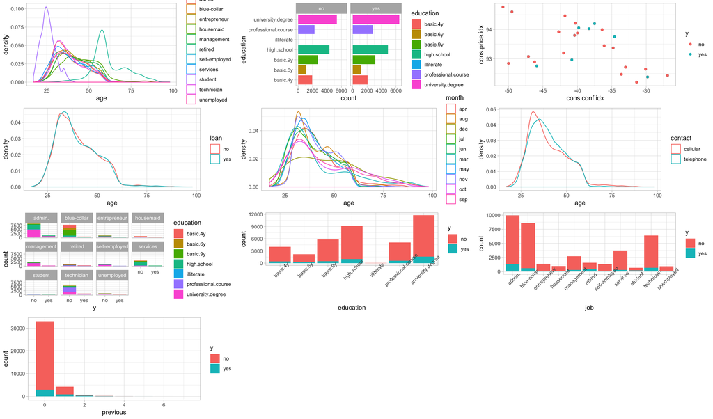

```r
gridExtra::grid.arrange(plot_1, plot_2, plot_3, plot_4, plot_5, plot_6, plot_7, plot_8, plot_9, plot_10)
```

```r
bank_num = bank_full
bank_num[,] <- sapply(bank_full[,], as.numeric)
```

```r
rf = randomForest(y ~ ., data = bank_full)
```

```r
rf$importance
```

```
##                MeanDecreaseGini
## age                   591.82437
## job                   504.74799
## marital               161.59546
## education             370.31301
## default                57.28295
## housing               132.97567
## loan                  101.67478
## contact                71.00005
## month                 249.15047
## day_of_week           342.73258
## duration             2401.89435
## campaign              283.51707
## pdays                 257.35037
## previous              101.90658
## poutcome              233.03872
## emp.var.rate          169.72007
## cons.price.idx        152.80013
## cons.conf.idx         185.07667
## euribor3m             819.29977
## nr.employed           484.95418
```

```r
pca = prcomp(bank_full[, c("emp.var.rate", "cons.price.idx", "cons.conf.idx", "euribor3m", "nr.employed")], center = TRUE, scale = TRUE)
# mat = scale(as.matrix(bank[, c("emp.var.rate", "cons.price.idx", "cons.conf.idx", "euribor3m", "nr.employed")]))
```

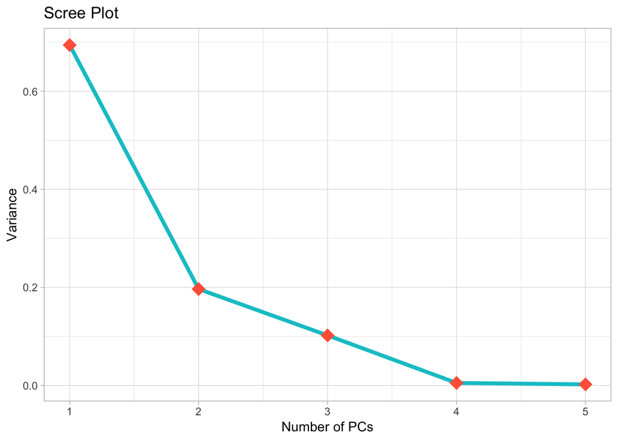

```r
evals = pca$sdev ^ 2
ggplot(mapping = aes(x = 1:length(pca$sdev), y = pca$sdev ^ 2 / sum(pca$sdev ^ 2))) +
  geom_line(color = "turquoise3", size = 1.5) +
  geom_point(size = 5, color = "tomato", shape = 18) +
  xlab("Number of PCs") +
  ylab("Variance") +
  ggtitle("Scree Plot")
```

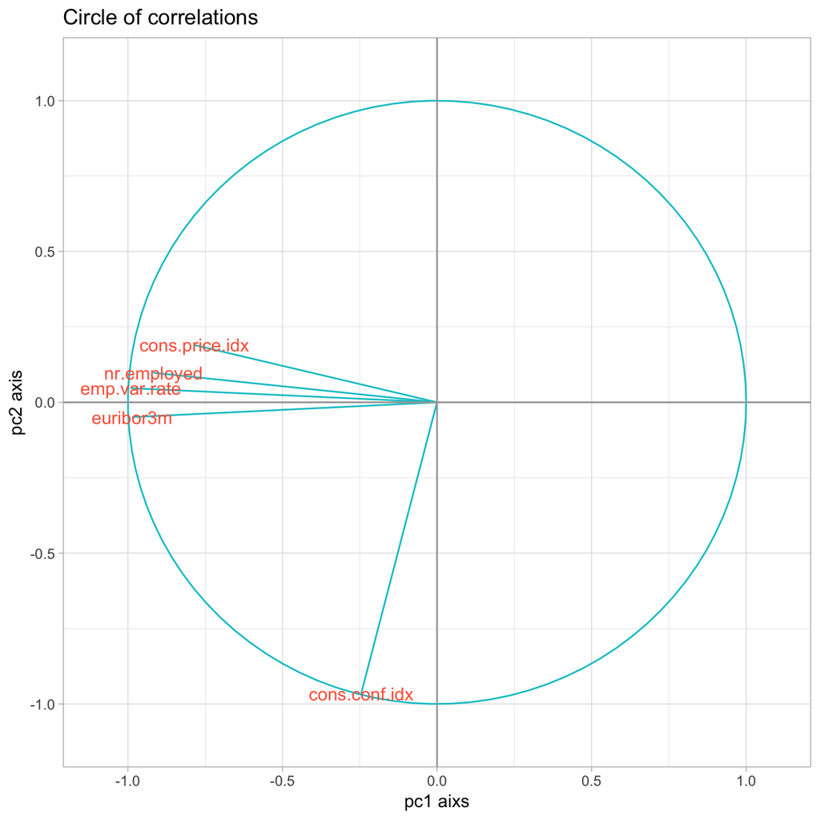

```r
# function to create a circle
circle = function(center = c(0, 0), npoints = 100) {
    r = 1
    tt = seq(0, 2 * pi, length = npoints)
    xx = center[1] + r * cos(tt)
    yy = center[1] + r * sin(tt)
    return(data.frame(x = xx, y = yy))
}

corcir = circle(c(0, 0), npoints = 100)

# create data frame with correlations between variables and PCs
correlations = as.data.frame(cor(bank_full[, c("emp.var.rate", "cons.price.idx", "cons.conf.idx", "euribor3m", "nr.employed")], pca$x))

# data frame with arrows coordinates
arrows = data.frame(x1 = c(0, 0, 0, 0, 0), y1 = c(0, 0, 0, 0, 0), x2 = correlations$PC1,
    y2 = correlations$PC2)

# geom_path will do open circles
ggplot() +
  geom_path(data = corcir, aes(x = x, y = y), colour = "turquoise3") +
  geom_segment(data = arrows, aes(x = x1, y = y1, xend = x2, yend = y2), colour = "turquoise3") +
  geom_text(data = correlations, aes(x = PC1, y = PC2, label = rownames(correlations)), color = "tomato") +
  geom_hline(yintercept = 0, colour = "gray65") +
  geom_vline(xintercept = 0, colour = "gray65") +
  xlim(-1.1, 1.1) +
  ylim(-1.1, 1.1) +
  labs(x = "pc1 aixs", y = "pc2 axis") +
  ggtitle("Circle of correlations")
```

```r
pca1 = prcomp(bank_full[, c("emp.var.rate", "cons.price.idx", "euribor3m", "nr.employed")])
trans = pca1$rotation[, 1]
bank = bank_full %>%
  mutate(econ.idx = -(emp.var.rate * trans[1] + cons.price.idx * trans[2] + euribor3m * trans[3] + nr.employed * trans[4])) %>%
  select(-c("emp.var.rate", "cons.price.idx", "euribor3m", "nr.employed"))
bank_full = bank_full %>%
  mutate(econ.idx = -(emp.var.rate * trans[1] + cons.price.idx * trans[2] + euribor3m * trans[3] + nr.employed * trans[4])) %>%
  select(-c("emp.var.rate", "cons.price.idx", "euribor3m", "nr.employed"))
```

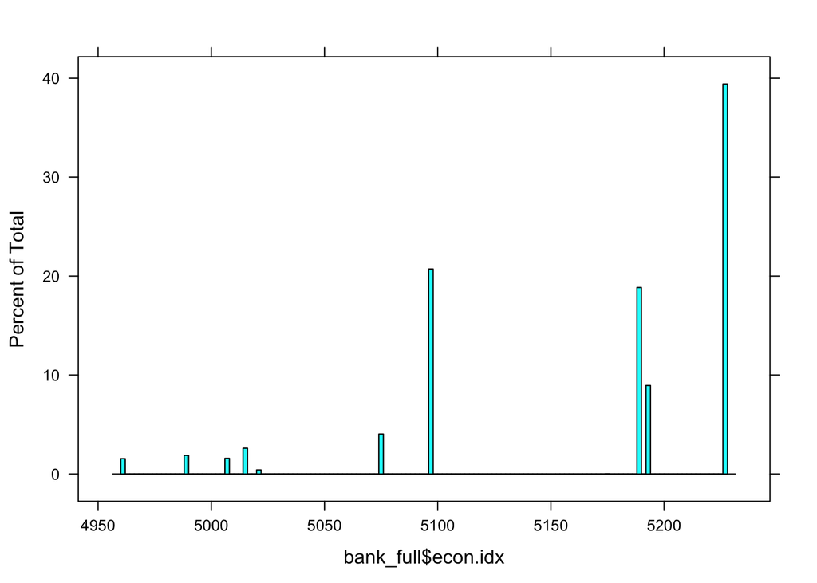

```r
histogram(bank_full$econ.idx, breaks = 100)
```